## Curso de R no IPÊ

### Script do dia 2

*Marcos V. C. Vital e participantes da turma de 2014*

Para mais material, acesse http://marcosvital.wordpress.com/

Este documento é o segundo de uma série que nasceu durante as atividades do “Curso de introdução ao uso do software R e suas aplicações estatísticas nas ciências biológicas”, realizado no IPÊ em dezembro de 2014.

Neste segundo guia nós vamos calcular algumas estatísticas descritivas, criar alguns gráficos básicos e realizar um teste T.

Todo o documento foi criado utilizando o software R, o programa RStudio e a linguagem Markdown. Para saber mais, acesse:

http://www.r-project.org/

http://www.rstudio.com

http://rmarkdown.rstudio.com/

**Antes de começar, carregue os dados necessários:**

```r
setwd("C:/R/Curso IPÊ")
dados<-read.table("pratica1.txt", h=T)
attach(dados)
```

#### Um pouquinho de estatística descritiva

Como era de se esperar, o R é capaz de calcular um monte de medidas comumente usadas na estatística, como média, desvio padrão, mediana e coisas do tipo. Então vamos ver rapidamente alguns exemplos. Vá executando cada um deles e observando o resultado:

```
mean(Riqueza)   #Média
var(Riqueza)        #Variância
sd(Riqueza)         #Desvio padrão

median(Riqueza) #Mediana

quantile(Riqueza)                       #Percentis
quantile(Riqueza, 0.9)                  #Apenas o percentil 90
quantile(Riqueza, c(0.1, 0.5, 0.9))     #Percentis 10, 50 e 90

#Podemos fazer cálculos com condições:
mean(Área[Ambiente=="primário"])        #Média da área para amb. primários

#E podemos combinar condições diferentes, como nos dois exemplos a seguir:

sd(Riqueza[Ambiente=="primário" & Abund_sp1>0])
#Desvio padrão da riqueza para ambientes primários e que possuam indivíduos da espécie 1.

var(Abund_sp1[Abund_sp1=!0])
#Variância da abund_sp1, quando seus valores são diferentes de zero ("=!" é o símbolo de "diferente")
```

Resumindo:

- `mean()` calcula média
- `var()` calcula variância
- `sd()` calcula desvio padrão
- `median()` calcula mediana
- `quantile()` calcula mediana, quartis e percentis

**Usando tapply**

A função `tapply()` é uma mão na roda! Ela serve para calcularmos um valor usando uma variável categórica como condição. É bem simples de usar e de se entender, veja:

```r
tapply(Abund_sp1, Ambiente, quantile)
```

```
## $primário
##   0%  25%  50%  75% 100%
##  0.0  1.0  2.5  3.0  6.0
##
## $secundário
##   0%  25%  50%  75% 100%
##    0    1    2    3    8
```

Agora tente com outros exemplos, como:

```
tapply(Riqueza, Ambiente, mean)
tapply(Riqueza, Ambiente, sd)
```

#### Vamos fazer alguns gráficos?

Agora vamos explorar algumas funcionalidades gráficas no R. O R é um software super flexível para se construir gráficos, e ele oferece opções que nos permite mexer em cada detalhe que desejarmos. Claro, isto vem com um custo: cada detalhe a ser alterado no gráfico normalmente é um novo argumento no comando que foi usado para gerá-lo. Duas coisas são importantes para fazermos bons gráficos no R: construir aos poucos, adicionando cada argumento e verificando se está funcionando; e usar muitos exemplos como referência, pois é mais fácil aprender com eles do que tentar consruir tudo “na marra”.

Então vamos começar!

**Criando histogramas simples**

Os histogramas são criados pela função `hist()`, e podem ser feitos bem rapidamente se você não se preocupar com detalhes do gráfico:

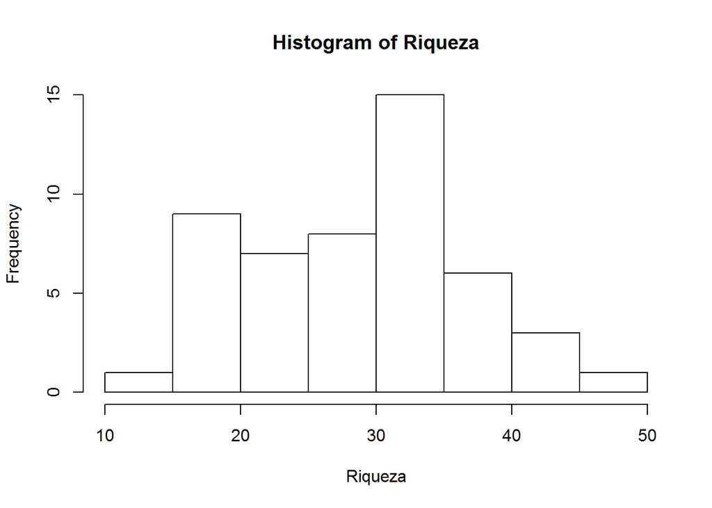

```r
hist(Riqueza)
```

Mas é claro que você pode querer ir além, então vamos mexer um pouco em alguns dos elementos deste gráfico:

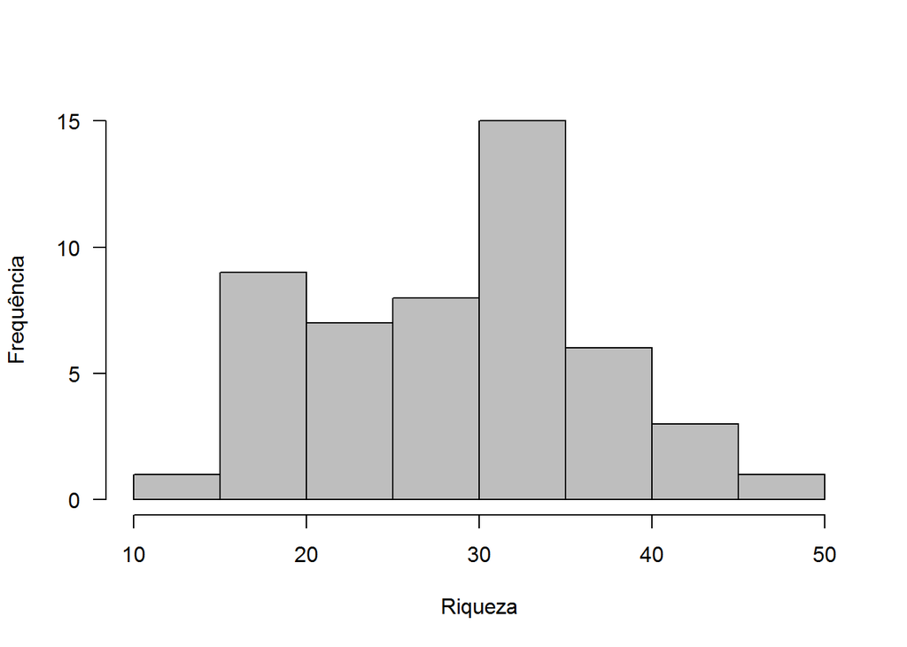

```r
hist(Riqueza, main=NULL, ylab="Frequência", las=1, col="gray")
```

Aqui usamos alguns argumentos que alteraram a aparência do histograma:

- `main` define o título do gráfico;
- `ylab` define o nome do eixo y;
- `las` define a orientação dos números (se fica deitados ou em pé);
- `col` altera as cores do gráfico;

**Agora vamos fazer gráficos de dispersão!**

O básico seria:

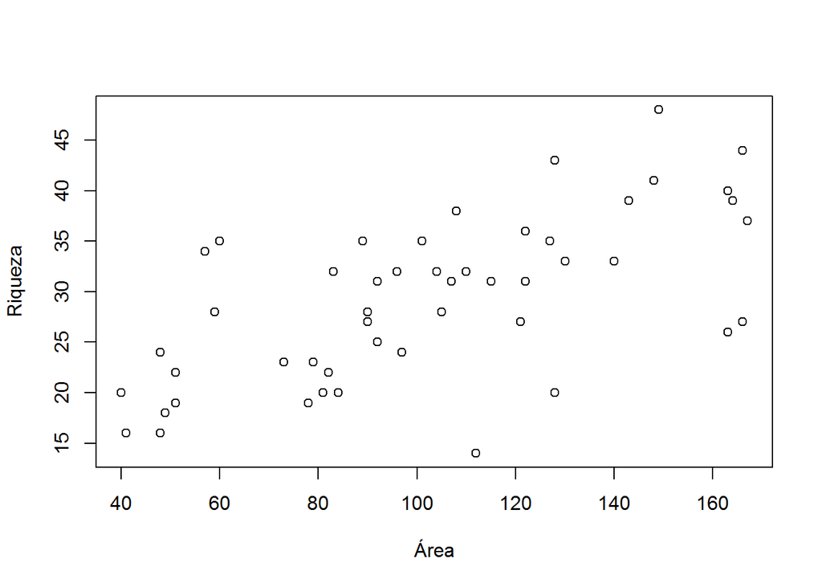

```r
plot(Riqueza~Área)
```

Note que usamos um “~” para denotar a relação entre as variáveis. Funciona sempre no formato: `Variável resposta~variável exxplicativa`.

De novo, vamos complicar um pouco e alterar elementos do gráfico com alguns argumentos:

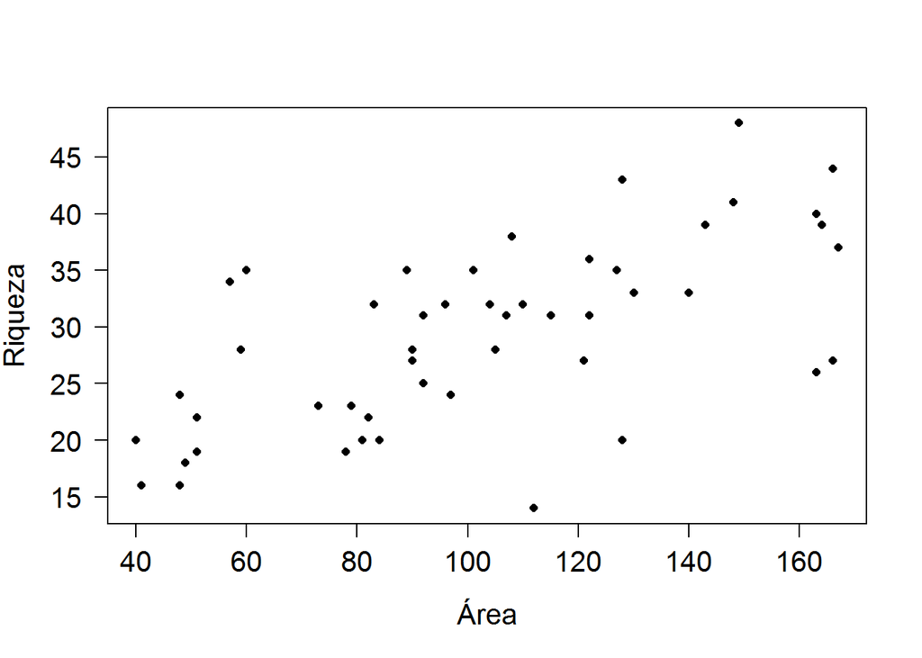

```r
plot(Riqueza~Área, las=1, pch=16, cex=0.8,
cex.axis=1.3, cex.lab=1.3)
```

Aqui usamos mais alguns argumentos:

- `pch` define o tipo de símbolo usado (Você pode chamar `?pch` para ver uma lista de símbolos);
- `cex` altera o tamanho dos símbolos;
- `cex.axis` e `cex.lab` alteram, respectivamente, os tamanhos dos números dos eixos e dos seus nomes;

Agora vamos complicar um pouco as coisas, e criar um gráfico de dispersão que inclua a categoria dos dados de acordo com uma variável categórica.

Ele pode ser feito de uma maneira bem rápida e grosseira com o seguinte comando:

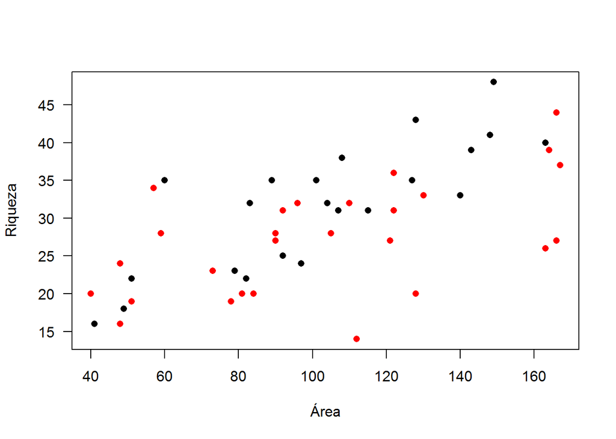

```r
plot(Riqueza~Área, las=1, pch=16, col=Ambiente)
```

Mas ele tem uma deficiência grande: as cores foram atribuídas automaticamente… Então vamos tentar de um jeito diferente, ok?

A proposta aqui é fazer o gráfico em duas etapas: primeiro vamos plotar parte dos dados, usando uma primeira categoria da nossa escolha, e depois vamos adicionar a segunda. Com isso, vamos ver um bocado de funções e argumentos novos! Vamos lá:

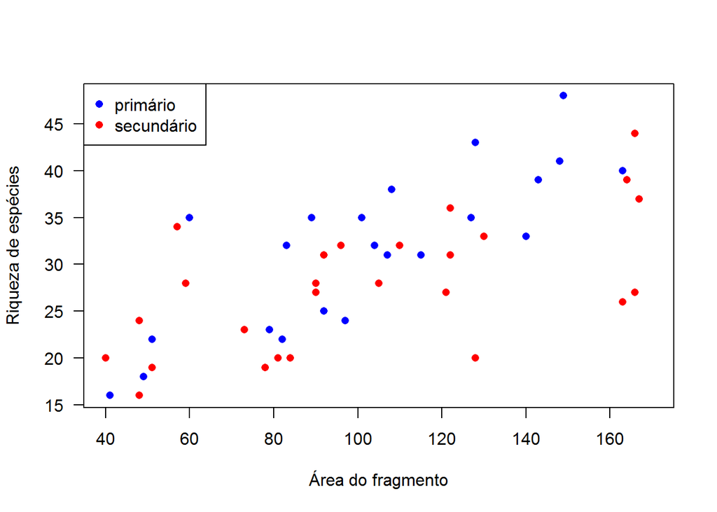

```r
plot(Riqueza[Ambiente=="primário"]~Área[Ambiente=="primário"],
las=1, pch=16, col="blue", xlim=c(40, 170),
ylab="Riqueza de espécies", xlab="Área do fragmento")

points(Riqueza[Ambiente=="secundário"]~Área[Ambiente=="secundário"],
pch=16, col="red")

legend("topleft", legend=levels(Ambiente), pch=16, col=c("blue", "red"))
```

Tome algum tempo para tentar digerir e entender todo o processo e argumentos utilizados. Algumas explicações rápidas:

- `xlim` serviu para delimitar o intervalo usado no eixo x;
- a função `points` serviu para adicionarmos pontos em um gráfico já aberto;
- a função `legend` serviu para adicionar a legenda;
- a função `levels` serviu para chamarmos os nomes das categorias da variável ambiente;

#### Agora, um teste T :)

Para finalizar este script, vamos fazer um teste T. Aqui vamos realizar o teste de maneira bem simples, testando a hipótese de que existe uma diferença na média da riqueza de espécies entre os dois tipos de ambiente.

Mas antes de começar, poode ser legal dar uma conferida nos pressupostos do teste! O teste T presume que: (i) os dados de cada categoria não difere do que seria esperado para uma distribuição normal e (ii) as variâncias são homogêneas.

Existem várias maneiras de se lidar com os pressupostos. Vamos aqui usar uma das mais simples (mas não necessariamente a melhor!): um teste de normalidade e um teste de homogeneidade de variâncias.

**Teste de normalidade**

Vamos usar a função `shapiro.test` para verificar a normalidade. Como precisamos fazer isto para cada categoria da variável Ambiente, vamos usá-la apartir de um `tapply`:

```r
tapply(Riqueza, Ambiente, shapiro.test)
```

```
## $primário
##
##  Shapiro-Wilk normality test
##
## data:  X[[1L]]
## W = 0.9693, p-value = 0.6937
##
##
## $secundário
##
##  Shapiro-Wilk normality test
##
## data:  X[[2L]]
## W = 0.9773, p-value = 0.7815
```

Prontinho!

Pelos resultados, os dados não diferem da distribuição normal, então podemos seguir adiante.

**Teste de homogeneidade de variâncias**

Vamos usar a função `leveneTest`, que faz parte do pacote `car`. É necessário carregar o pacote, e você vai precisar instalá-lo caso não o tenho no seu computador (faça isso pelo menu Pacotes, e use a opção Instalar Pacotes; será preciso uma conexão com a internet).

```r
library(car)    #Carrega o pacote necessário
leveneTest(Riqueza~Ambiente)
```

```
## Levene's Test for Homogeneity of Variance (center = median)
##       Df F value Pr(>F)
## group  1  0.5134 0.4771
##       48
```

Tudo beleza de novo, pressuposto atendido. Então vamos fazer o teste T:

```r
t.test(Riqueza~Ambiente, var.equal=T)
```

```
##
##  Two Sample t-test
##
## data:  Riqueza by Ambiente
## t = 2.0171, df = 48, p-value = 0.0493
## alternative hypothesis: true difference in means is not equal to 0
## 95 percent confidence interval:
##  0.01431068 8.94023478
## sample estimates:
##   mean in group primário mean in group secundário
##                 31.72727                 27.25000
```

E pronto, podemos concluir que existe uma diferença estatisticamente significativa na riqueza de espécies entre os ambientes, com mais espécies nos ambientes de mata primária.

Vamos ver as funções e argumentos vistos até agora:

- `shapiro.test` realiza um teste de normalidade;
- `leveneTest` realiza um teste de homogeneidade de variâncias;
- `t.test` realiza o teste T.
- No teste T, o argumento `var.equal` define se o teste presume variâncias homogêneas;

**Pra terminar, vamos fazer um gráfico!**

Vamos usar uma função do pacote `sciplot` para criar um gráfico que mostra as médias e erros padrões:

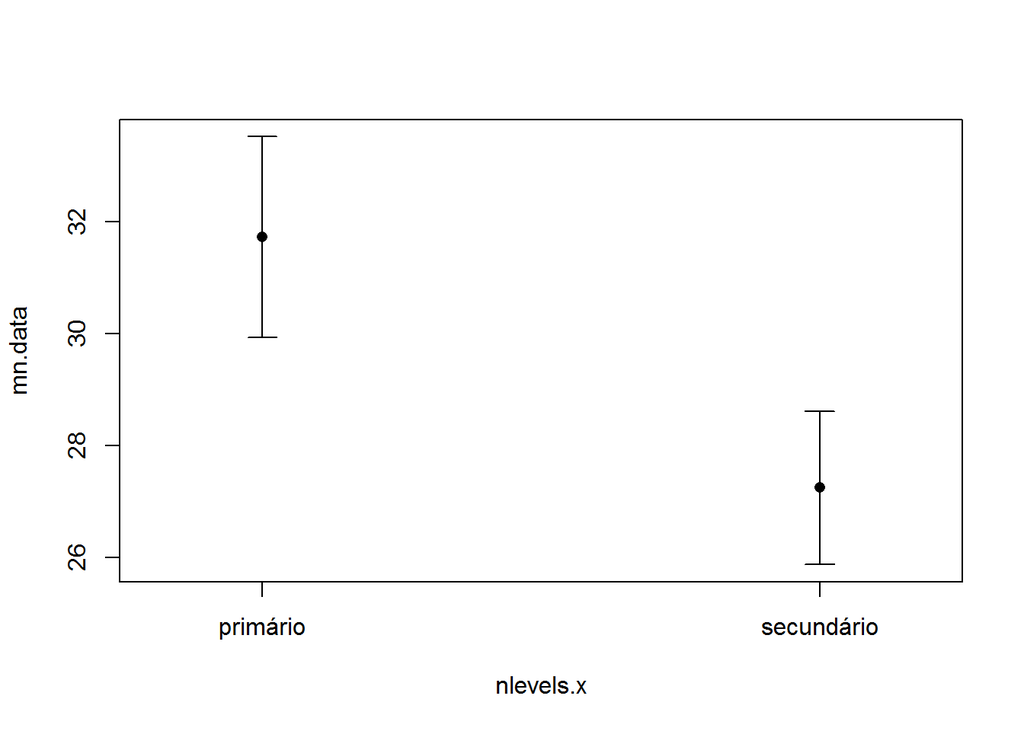

```r
library(sciplot)

lineplot.CI(Ambiente, Riqueza, type="p")
```

Fizemos o gráfico bem grosseirão, mas lembre-se de que ele pode ser editado para ficar mais apresentável.

**E por hoje é só! ;)**